# Preprocessing & Descriptive Analysis

hcp4715

2024-09-11

# About the data

## The full dataset form PSA001

Script: `psa001_RR2_analysis.Rmd`

1. Joining three data files `psa001_exp_data.csv`, `psa001_session.csv`, and `psa001_quest_data.csv` to `psa001_rating_raw.csv`.
2. Joining the above data with data from Oosterhof & Todorov, (2008);
3. Excluded invalid data and got `psa001_ind.csv`, but note the rating could not be used in our analysis because they used averaged rating from two ratings of the same subject.

The final subject should be “11,481 participants (69.6% women, 29.7% men, 0.7% other; mean age = 22.6 years), nested within 45 countries, nested within 11 regions,” from Hester, Xie, & Hehman (2021).

Exploratory dataset was generated by `psa001_RR2_subset.Rmd`, using the exactly same procedure as above. The final valid subjects are 4143.

```r
# install pacman if not installed yet
if (!require("pacman")) install.packages("pacman")
# use pacman::p_load to load or install tidyverse
pacman::p_load(tidyverse)
```

### Load the “psa001_ratings_raw_subset.csv”

```r
df_raw_subset <- read.csv(here::here("1_data", "ExploratoryData", "data", "psa001_ratings_raw_subset.csv"))

regions <- read.csv(here::here("1_data", "ExploratoryData", "data", "regions.csv"))
```

### Load Stimulus Info

```r
stim_info <- read_csv(here::here("1_data", "ExploratoryData", "data", "psa001_cfd_faces.csv")) %>%
      dplyr::mutate(ethnicity = recode(Race, "A" = "asian", "B" = "black", "L" = "latinx", "W" = "white"),
                    gender = recode(Gender, "M" = "male", "F" = "female")
                    )
stim_info %>%
      group_by(ethnicity, gender) %>%
      summarise(n = n(),
                mean_age = round(mean(Age), 2),
                sd_age = round(sd(Age), 2)
                ) %>%
      knitr::kable("html") %>%
      kableExtra::kable_styling("striped")
```

| ethnicity | gender | n | mean_age | sd_age |
| --- | --- | --- | --- | --- |
| asian | female | 15 | 26.15 | 3.33 |
| asian | male | 15 | 26.40 | 3.21 |
| black | female | 15 | 27.00 | 3.51 |
| black | male | 15 | 28.07 | 4.27 |
| latinx | female | 15 | 25.27 | 2.42 |
| latinx | male | 15 | 26.31 | 4.00 |
| white | female | 15 | 25.77 | 3.03 |
| white | male | 15 | 26.06 | 4.46 |

```r
stim_n_male <- sum(stim_info$gender == "male")
stim_n_female <- sum(stim_info$gender == "female")
mean_age <- mean(stim_info$Age) %>% round(2)
sd_age <- sd(stim_info$Age) %>% round(2)
min_age <- min(stim_info$Age)
max_age <- max(stim_info$Age)
```

Stimuli in our study will be an open-access, full-color, face image set consisting of 60 men and 60 women (mean age=26.38 years, SD=3.57 years, range=18.7307692 to 34.9310345 years), taken under standardized photographic conditions (Ma et al., 2015).

### Add region information to the data

```r
df_subset <- df_raw_subset %>%
  rename(qcountry = country) %>%
  separate(lab, c("country", "lab")) %>%
  left_join(regions, by = "country")

# df_regions <- df_full %>%
#   dplyr::mutate(lab  = substr(lab, 1, nchar(lab)- 4)) %>%
#   dplyr::mutate(country = lab) %>%
#   dplyr::left_join(regions, by = "country")
```

### Graph distributions for trait by region

```r
# plot styles
bgcolor <- "white"
textcolor <- "black"
PSA_theme <- theme(
    plot.background = element_rect(fill = bgcolor, color = NA),
    panel.background = element_rect(fill = NA, color = "grey"),
    legend.background = element_rect(fill = NA),
    panel.grid.major = element_blank(),
    panel.grid.minor = element_blank(),
    text = element_text(color = textcolor, size=15),
    axis.text = element_text(color = textcolor, size=10),
    strip.text.y = element_text(angle = 0, hjust = 0)
  )
```

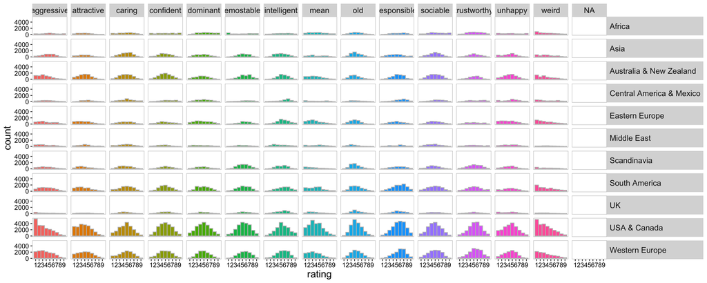

```r
ggplot2::ggplot(df_subset, aes(rating, fill = trait)) +
      geom_histogram(binwidth = 1, color = "grey", show.legend = F) +
      facet_grid(region ~ trait, space = "free") +
      scale_x_continuous(breaks = 1:9) +
      PSA_theme
```

### remove invalid participants

```r
identical_rating_threshold <- 0.75 * 120 # use this for registered analyses

inv_participants <- df_subset %>%
      filter(block == 1) %>%
      count(user_id, region, trait, rating) %>%
      group_by(user_id, region, trait) %>%
      filter(n == max(n)) %>%                  # find most common rating for each P
      ungroup() %>%
      filter(n >= identical_rating_threshold)  # dplyr::select Ps who gave the same rating to >= 75% of stimuli, 219 participants


df_valid_subset <- df_subset %>%
      group_by(user_id, trait) %>%
      filter(# did not complete 1+ ratings for each of 120 stimuli
            dplyr::n_distinct(stim_id) == 120,
            !is.na(region)   # did not specify region (none expected)
            ) %>%
      anti_join(inv_participants, by = "user_id")
```

## Participant Demographics

Total: 4143

```r
df_valid_subset %>%
      group_by(user_id, language) %>%
      summarise() %>%
      ungroup() %>%
      group_by(language) %>%
      summarise(n = n()) %>%
      knitr::kable("html") %>%
      kableExtra::kable_styling("striped")
```

| language | n |
| --- | --- |
| EL | 35 |
| ENG | 2104 |
| ES-PE | 39 |
| FAS | 17 |
| FR-BE | 30 |
| FR-CH | 39 |
| FRE | 80 |
| GER | 164 |
| HU | 66 |
| ITA | 55 |
| NL | 85 |
| NOR | 120 |
| POL | 15 |
| PT | 27 |
| PT-BR | 72 |
| RO | 10 |
| RU | 80 |
| SLO | 96 |
| SPA | 618 |
| SRP | 25 |
| SV | 72 |
| THA | 32 |
| TUR | 101 |
| ZH-CN | 36 |
| ZH-S | 125 |

```r
by_region <- df_valid_subset %>%
  group_by(user_id, region) %>%
  summarise() %>%
  ungroup() %>%
  group_by(region) %>%
  summarise(n = n()) %>%
  add_row(region = "TOTAL", n = n_distinct(df_valid_subset$user_id)) %>%
  knitr::kable("html") %>%
  kableExtra::kable_styling("striped")
```

```r
# save_kable(by_region, "figures/n_by_region.html")

by_region
```

| region | n |
| --- | --- |
| Africa | 188 |
| Asia | 274 |
| Australia & New Zealand | 373 |
| Central America & Mexico | 167 |
| Eastern Europe | 292 |
| Middle East | 149 |
| Scandinavia | 243 |
| South America | 466 |
| UK | 132 |
| USA & Canada | 1187 |
| Western Europe | 672 |
| TOTAL | 4143 |

### Age and sex distribution per region

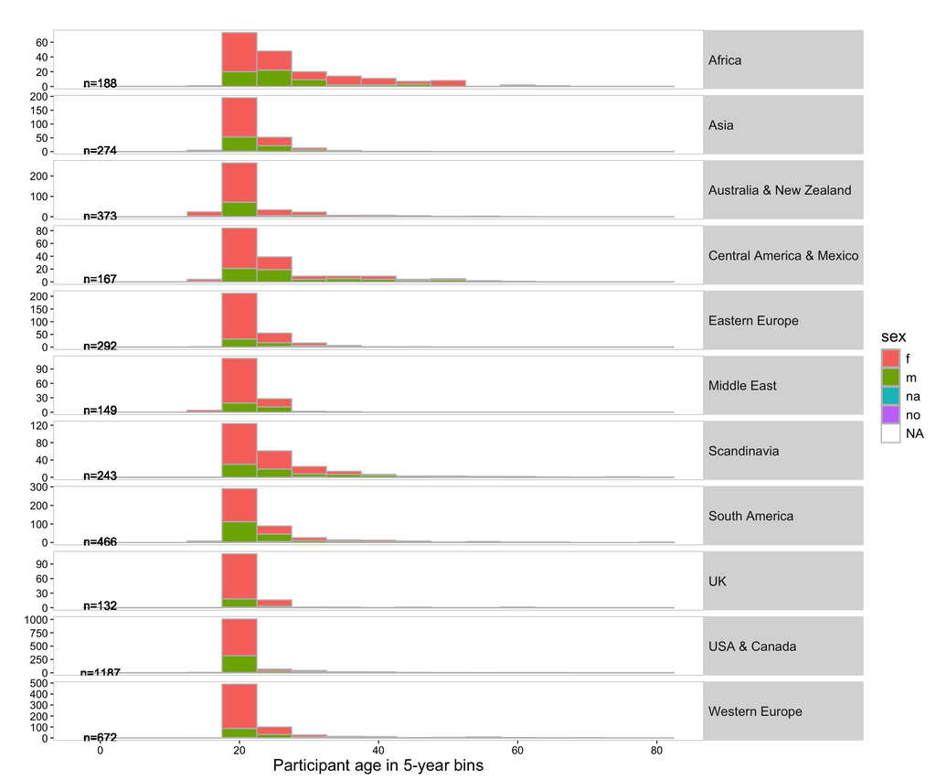

```r
df_valid_subset %>%
  group_by(user_id, sex, age, region) %>%
  summarise() %>%
  ungroup() %>%
  group_by(region) %>%
  mutate(n = n()) %>%
  ungroup() %>%
  ggplot(aes(as.numeric(age), fill = sex)) +
  geom_histogram(binwidth = 5, color = "grey") +
  geom_text(aes(x=0, y=5, label = paste0("n=",n)), color = "black") +
  labs(title="", y="", x="Participant age in 5-year bins") +
  facet_grid(region~., scales="free_y") +
  PSA_theme
```

### Participants per trait per region

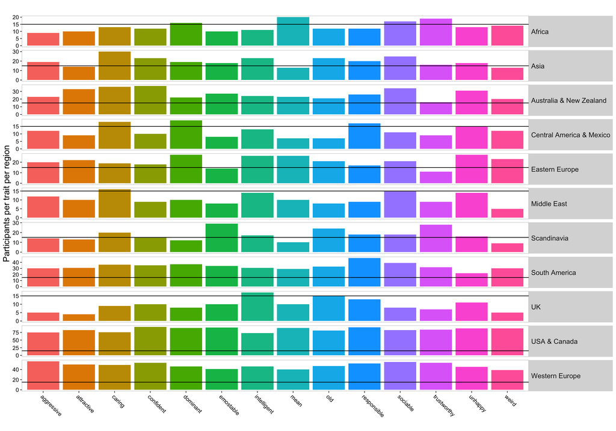

```r
df_valid_subset %>%
  group_by(trait, region) %>%
  summarise(n = n_distinct(user_id)) %>%
  ggplot(aes(trait, n)) +
  geom_col(aes(fill = trait), show.legend = F) +
  geom_hline(yintercept = 15) +
  facet_grid(region~., scale = "free") +
  labs(title="", x="", y="Participants per trait per region") +
  theme( axis.text.x = element_text(angle = -45, hjust = 0) ) +
  PSA_theme
```

```r
# ggsave("figures/participants_per_trait_per_region.png", width = 15, height = 8)
```

### Participants per lab

```r
labs <- df_valid_subset %>%
  unite(lab, country, lab) %>%
  group_by(region, lab, user_id) %>%
  summarise() %>%
  ungroup() %>%
  count(region, lab) %>%
  arrange(region, lab)
knitr::kable(labs) %>%
  kableExtra::kable_styling("striped")
```

| region | lab | n |
| --- | --- | --- |
| Africa | KEN_001 | 60 |
| Africa | KEN_002 | 65 |
| Africa | NGA_001 | 17 |
| Africa | RSA_001 | 18 |
| Africa | RSA_002 | 28 |
| Asia | CHN_001 | 18 |
| Asia | CHN_006 | 36 |
| Asia | CHN_007 | 21 |
| Asia | CHN_014 | 32 |
| Asia | MAS_001 | 20 |
| Asia | MAS_002 | 19 |
| Asia | MAS_003 | 15 |
| Asia | MAS_004 | 45 |
| Asia | TAI_001 | 11 |
| Asia | TAI_002 | 25 |
| Asia | THA_001 | 32 |
| Australia & New Zealand | AUS_004 | 32 |
| Australia & New Zealand | AUS_005 | 29 |
| Australia & New Zealand | AUS_006 | 72 |
| Australia & New Zealand | AUS_007 | 89 |
| Australia & New Zealand | AUS_008 | 34 |
| Australia & New Zealand | AUS_011 | 31 |
| Australia & New Zealand | AUS_014 | 29 |
| Australia & New Zealand | NZL_001 | 7 |
| Australia & New Zealand | NZL_002 | 50 |
| Central America & Mexico | ECU_001 | 40 |
| Central America & Mexico | MEX_002 | 70 |
| Central America & Mexico | MEX_003 | 24 |
| Central America & Mexico | SLV_001 | 33 |
| Eastern Europe | HUN_001 | 66 |

[output cut: 96 more lines]